# Curso de introducción a la programación en python

**Autor: Luis Fernando Apáez Álvarez**

## Clase 19: Recursión

- Primeros ejemplos
- Factorial a fondo
- Último ejemplo

## Primeros ejemplos

Básicamente, una función recursiva es una función que se llama a sí misma en el proceso de ejecución. Su funcionamiento es muy similar a la iteraciones que vimos en clase pasadas. Comenzaremos trabajando con el siguiente ejemplo que posteriormente explicaremos paso a paso:

```python
# Cuenta regresiva

def cuentaRegresiva(x):
    x -= 1
    if x >= 0:
        print(x)
        cuentaRegresiva(x)
    else:
        print('Fin')

cuentaRegresiva(4)
```

```
3
2
1
0
Fin
```

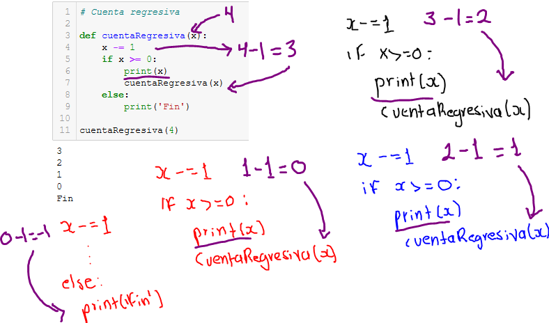

donde

- Paso 1: una vez ingresado el valor de `x=4` procedemos a quitarle uno y volver a asignar este valor a la variable `x`, de tal manera `x=3`, después imprimimos este valor y posteriormente volvemos a aplicar la función `cuentaRegresiva(x)`
- Paso 2: el valor de `x=3`ingresa a nuestra función por lo que se le resta uno y se le vuelve a asignar este valor, es así como `x=2` y es impreso este valor, luego, nuevamente es ingresado en la función `cuentaRegresiva(x)`.

Continuaremos con este procedimiento hasta que `x=0` pues, una vez que dicho valor es impreso y es ingresado a la función `cuentaRegresiva(x)`, una vez que le quitemos uno tendremos como resultado `x=-1` por lo que pasaremos a la ejecución del código correspondiente al `else` de nuestro condicional `if`, lo cual regresa el mensaje `'Fin'`.

Podemos ver otro ejemplo sobre funciones recursivas en Python utilizando el factorial de un número. Recordemos que dado $n\in\mathbb{N}$ tenemos que

$$ n!=n(n-1)\cdots3\cdot2\cdot1 $$

Ahora, podemos implemenar lo anterior mediante funciones recursivas:

```python
# definimos la función

def factorial(n):
    if n == 0 or n == 1:
        resultado = 1
    elif n > 1:
        resultado = n * factorial(n - 1)
    return resultado

# probamos nuestra función
factorial(5)
```

```
120
```

donde al ingresar el 5 a la función obtenemos que `resultado = 5 * factorial(4)`, luego al asignarle el 4 a la función tendremos que `resultado = 4 * factorial(3)` y así hasta obtener que `resultado = 2 * factorial(1)`, donde `factorial(1)` **retorna** como resultado 1 y por ende tendremos que

```
resultado = 5 * 4 * 3 * 2 * 1
```

o lo que es lo mismo obtenemos el valor de `resultado` final el cual es 120.

Veamos que

```python
factorial(4)
```

```
24
```

también puede explicarse observando que

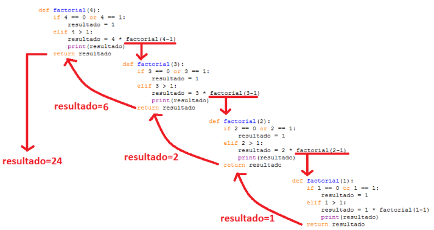

## Factorial a fondo

Para finalizar volvamos a ver la función recursiva que nos arroja el factorial de un número, observando cuidadosamente cada ejecución cuando llamamos a dicha función:

```python
# definimos la función

def factorial(n):
    print("Número en ejecución", n)
    if n == 0 or n == 1:
        resultado = 1
    elif n > 1:
        resultado = n * factorial(n - 1)
        print("Resultado", resultado)
    return resultado

# probamos nuestra función
factorial(5)
```

```
Número en ejecución 5
Número en ejecución 4
Número en ejecución 3
Número en ejecución 2
Número en ejecución 1
Resultado 2
Resultado 6
Resultado 24
Resultado 120
```

```
120
```

- Notemos que primero se imprime el mensaje *Número de ejecución 5* y ejecutaremos las líneas de código referentes al `elif` (es importante recordar que la ejecución en Python es de arriba a abajo línea por línea), sin embargo cuando estemos en la línea de ejecución `resultado = n * factorial(n - 1)` tendremos que `resultado = 5 * factorial(4)` y la función `factorial()` se volvera a llamar por lo que no se ejecutara en ese momento la línea siguiente `print("Resultado", resultado)`. De tal manera, en este bloque tendremos pendiente obtener `resultado = 5 * factorial(4)`.
- Una vez pasado al siguiente bloque de ejecución se imprime el mensaje *Número de ejecución 4* y tendremos la ejecución de la línea de código `resultado = 4 * factorial(3)` la cual quedará pendiente y además la función se vuelve a llamar.
- Una vez pasado al siguiente bloque de ejecución se imprime el mensaje *Número de ejecución 3* y tendremos la ejecución de la línea de código `resultado = 3 * factorial(2)` la cual quedará pendiente y además la función se vuelve a llamar.
- Una vez pasado al siguiente bloque de ejecución se imprime el mensaje *Número de ejecución 2* y tendremos la ejecución de la línea de código `resultado = 2 * factorial(1)` la cual quedará pendiente y además la función se vuelve a llamar.
- Continuando con este procedimiento se imprime el mensaje *Número de ejecución 1* y en este caso se ejecutará la línea de código dentro de la condición del `if`, esto es `resultado = 1`. De ahí pasamos a la línea `return resultado` lo cual arroja de llamar a la función `factorial(1)` el valor de 1 por lo dicho anteriormente. Una vez que ya tenemos un resultado fijo se procede a dar el resultado de las operaciones que quedaron pendientes.
- De inmediato regresamos a la línea que quedó pendiente de ejecución `resultado = 2 * factorial(1)` lo cual asigna el valor de 2 en la variable `resultado` y después se ejecuta la línea inmediata siguiente `print("Resultado", 2)`. Es así como tenemos que, al llamar la función `factorial(2)`, se nos regresa como resultado el valor de 2.
- Luego ejecutamos `resultado = 3 * factorial(2)` el cual asigna el valor de 6 a la variable `resultado` pues `factorial(2)` arroja el valor de 2. Después se imprime `print("Resultado", 6)`. Y así sucesivamente.

## Último ejemplo

Finalmente vamos a crear un función recursiva para calcular los números de fibonacci. Recordemos que el n-ésimo número de Fibonacci se obtiene a partir de los dos anteriores, esto es:

$$ F_{n}=F_{n-1}+F_{n-2}, \ \ \ n \geq 2 $$

Por ejemplo, tomando los primeros dos números de la sucesión de Fibonacci $1$ y $1$ podemos obtener el tercer término el cual es $1+1=2$, el cuarto término el cual es $1+2=3$, el quinto término el cual es $2+3=5$, etcétera.

Lo que haremos será que nuestra función devuelva 1 cuando el término a buscar ($n$) sea 1 ó 2 y en los demás casos devolverá el valor de `fibonacci(n-1) + fibonacci(n-2)`. Por ejemplo, si $n=4$ entonces la función devolverá el valor de `fibonacci(3) + fibonacci(2)` que es lo mismo que `fibonacci(3) + 1`. Luego, para obtener `fibonacci(3)` se tedrá que la función devolverá el valor de resultante de `fibonacci(2) + fibonacci(1)` lo cual equivale a $1+1=2$ y por ende, regresando a la ejecución pendiente `fibonacci(3) + fibonacci(2)` tendremos el valor de $2+1=3$. Lo anterior se puede implementar en código como sigue:

```python
# Definimos la función

def fibonacci(n):
    if n == 1:

        # el primer término de la sucesión es el 1
        return n

    elif n == 2:

        # el segundo término de la sucesión es el 1
        return n - 1

    return fibonacci(n-1) + fibonacci(n-2)
```

```python
# probamos nuestra función

for i in range(1,7):
    print(f'El término {i} de la sucesión es: {fibonacci(i)}')
```

```
El término 1 de la sucesión es: 1
El término 2 de la sucesión es: 1
El término 3 de la sucesión es: 2
El término 4 de la sucesión es: 3
El término 5 de la sucesión es: 5
El término 6 de la sucesión es: 8
```